# Tackling the Health Crises in Africa

### by Gift Omodu

### Data Overview

The data consist of Africa health records from 1990 to 2019. These records includes: Causes of death, Number of death by age groups, Medical doctors per 10,000 population, Country codes, World population, Health expenditure(% of GDP).

## INSIGHTS

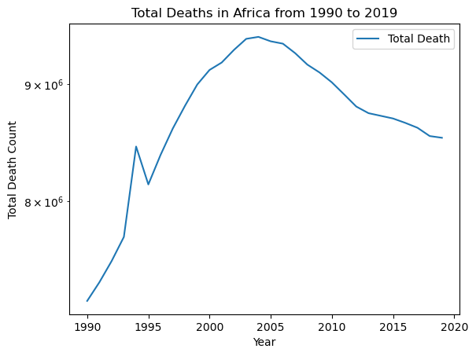

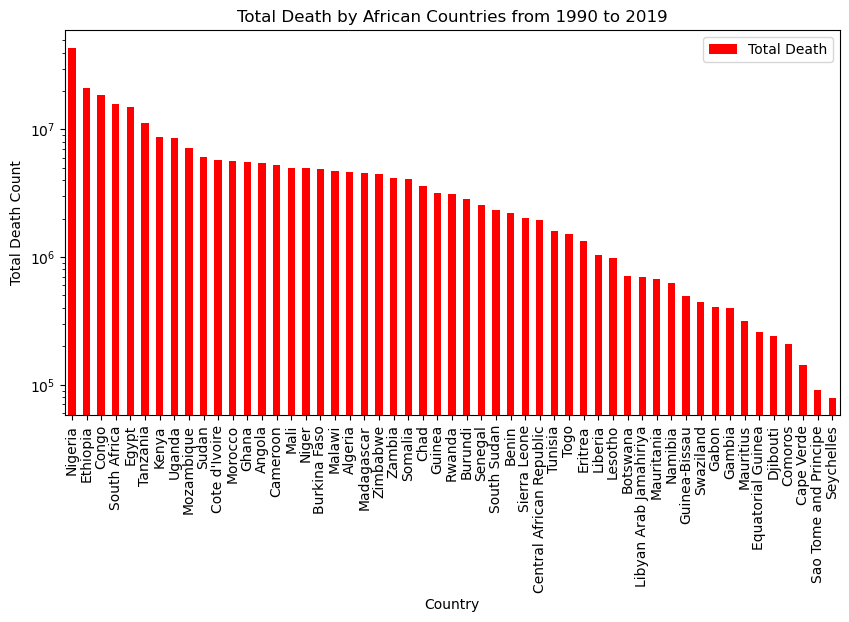

The first five bars represents the top five highest death count by country. The data reveals that Seychelles had the lowest death rate and Nigeria accounting for the highest.

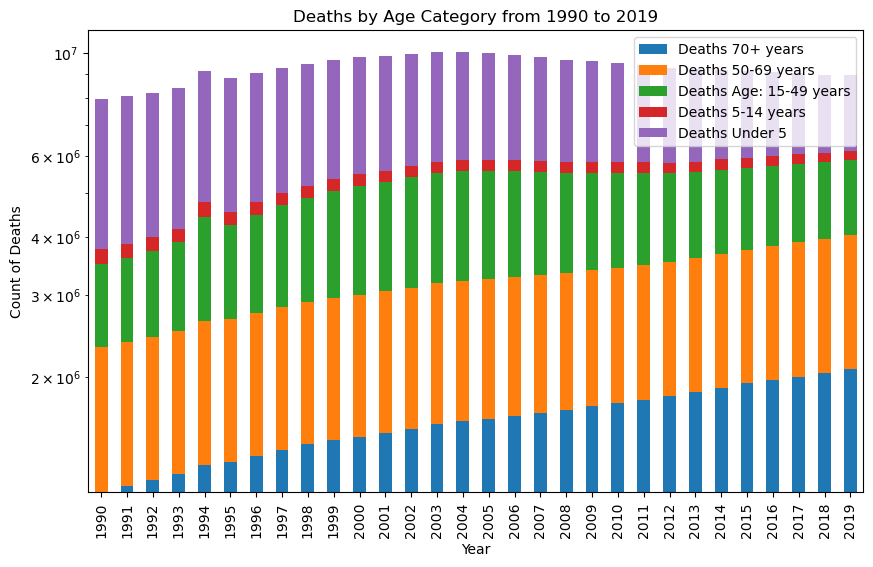

In all five age groups, we can see a pattern in death population across 1990 to 2019. The death toll for persons above 50 years increased gradually over the years. That of group 15-49 years witnessed a gentle rise and fall in death population. The death toll for the 5-14 years groups are associated with a gentle rise from 1990 with a spike in 1994, then declining the next year with a gentle rise up until 2004 where it remained relatively fixed till 2013 and increased further from there. The under 5 years groups had a gentle rise from 1990, reaching a peak at 2004 and then falling gradually.

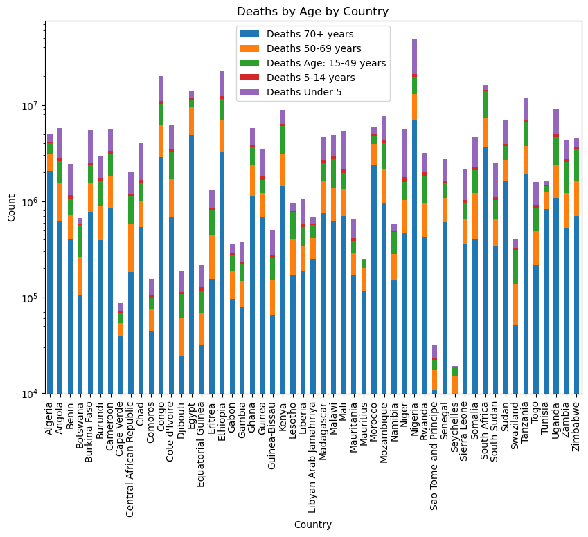

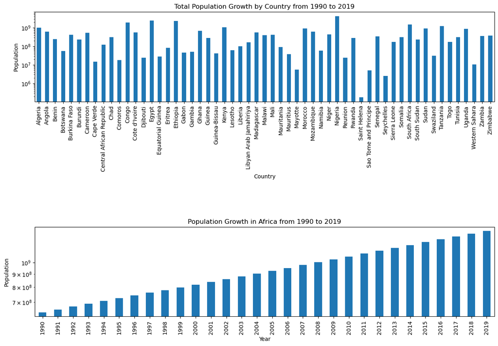

The fisrt chart shows the total population growth by country from 1990 to 2019.

The second chart shows the population growth in Africa from 1990 to 2019.

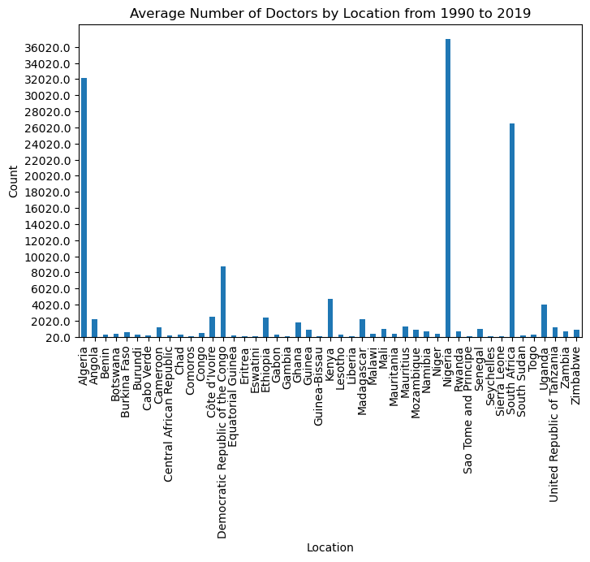

The average number of doctors in this chart shows that Nigeria has had the highest with an average of 35,000 doctors per year.

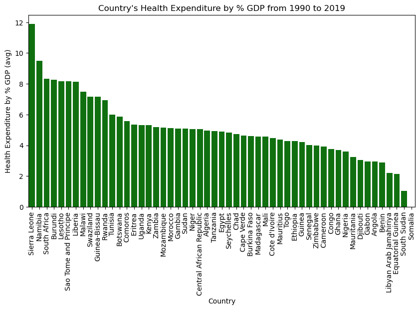

From the data above, we can clearly see that Sierra Leone has spent more on health in terms of comparison with their GDP followed by Namibia. The country with the least is South Sudan. Somalia has no records owing to the tension in the area.

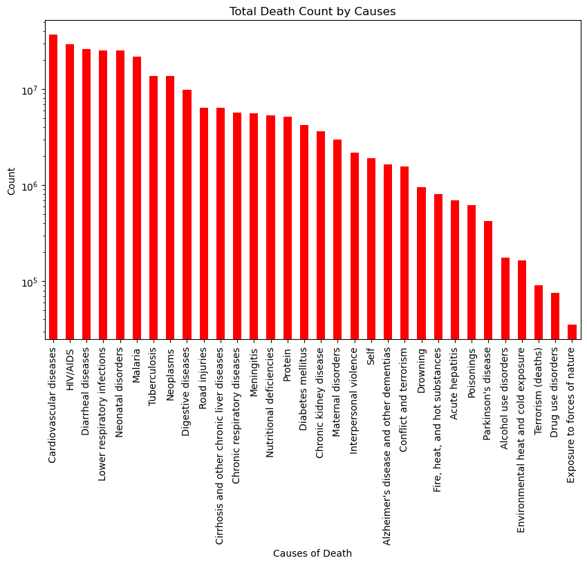

The chart shows the prevalent causes of death in Africa. A greater population is likely to die by cardiovascular diseases, HIV/AIDS, diarrheal diseases, etc. Fewer than 100,000 died by the forces of nature.

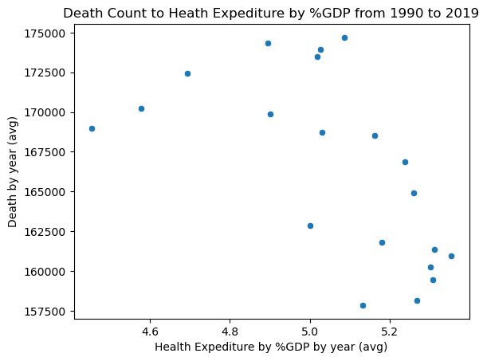

The chart shows that as the health expenditure increased, the death count reduced.

## RECOMMENDATION

From the insights generated, I can recommend that:

1. Africa needs to have an efficient plan to take care of its elderly.
2. Increase spending in the health sector.
3. Employ more doctors especially in countries with a higher population.
4. Set up measures to tackle cardiovascular diseases, HIV/AIDS, diarrheal, etc.